# Data-driven identification of US communities at additional risk for COVID-19 related health conditions

# Data sources used below

- COVID-19 tracking: https://covidtracking.com/api/
- CDC 500 Cities (2016-2017 estimates): https://chronicdata.cdc.gov/browse?category=500+Cities
- XY Exposome Data Warehouse, US Census estimated (2015 5-year estimate): https://www.census.gov/programs-surveys/acs

# Query the Current Covid Cases in the United States

```r
# from covidtracking.com API
#current_covid <- read_csv(url('http://covidtracking.com/api/states.csv')) #http://covidtracking.com/api/states.csv
current_covid <- read_csv('./states.csv')
```

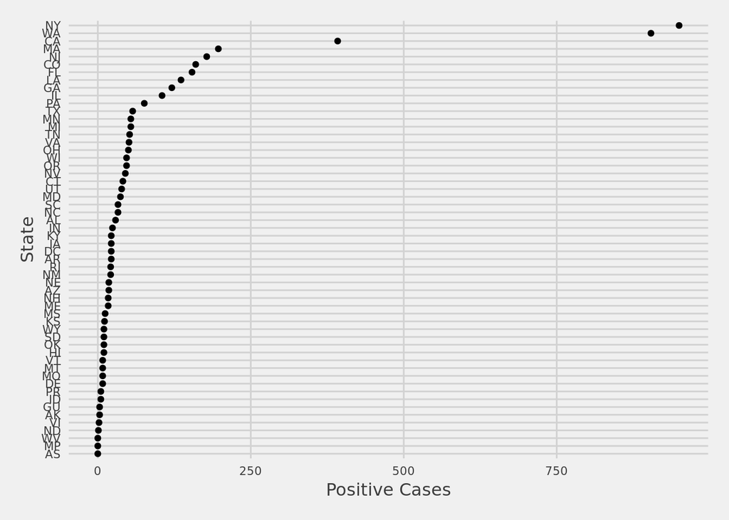

```r
current_covid <- current_covid %>% mutate(state = fct_reorder(state, (positive)))
p <- ggplot(current_covid, aes(state, positive))
p <- p + geom_point() + coord_flip()
p <- p + theme_fivethirtyeight() + theme(axis.title = element_text(), legend.position = 'none', axis.text = element_text(size=8)) + labs(y='Positive Cases', x='State')
p
```

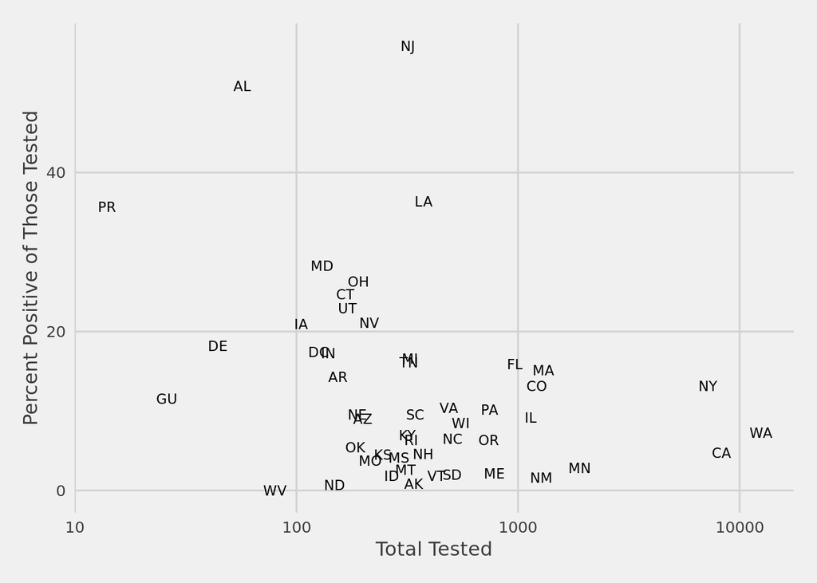

```r
p <- ggplot(current_covid, aes((positive+negative), I((positive/(positive+negative))*100), label=state))
p <- p + geom_text(size=3) + ylab('Fraction Positive') + xlab('Total Tested') + scale_x_log10()
p <- p + theme_fivethirtyeight() + theme(axis.title = element_text(), legend.position = 'none') + labs(x='Total Tested', y='Percent Positive of Those Tested')
p
```

```r
datatable(current_covid %>% arrange(desc(positive)))
```

|  | state | positive | negative | pending | death | total | lastUpdateEt | checkTimeEt |
| --- | --- | --- | --- | --- | --- | --- | --- | --- |
| 1 | NY | 950 | 6256 |  | 7 | 7206 | 3/16 15:00 | 3/17 01:43 |
| 2 | WA | 904 | 11582 |  | 48 | 12486 | 3/16 18:45 | 3/17 00:45 |
| 3 | CA | 392 | 7924 |  | 6 | 8316 | 3/16 07:47 | 3/17 01:28 |
| 4 | MA | 197 | 1107 |  |  | 1304 | 3/16 16:00 | 3/17 01:47 |
| 5 | NJ | 178 | 140 | 20 | 2 | 338 | 3/16 13:00 | 3/17 01:46 |
| 6 | CO | 160 | 1056 |  | 1 | 1216 | 3/16 17:00 | 3/17 01:28 |
| 7 | FL | 154 | 816 | 848 | 5 | 1818 | 3/16 18:00 | 3/17 00:59 |
| 8 | LA | 136 | 238 |  | 3 | 374 | 3/16 18:30 | 3/17 01:47 |
| 9 | GA | 121 |  |  | 1 | 121 | 3/16 12:00 | 3/17 01:36 |
| 10 | IL | 105 | 1038 |  |  | 1143 | 3/16 00:00 | 3/17 01:04 |

[output cut: 46 more lines]

## Load in the 500 Cities Data, merged with EDW on a census-tract level

```r
fh_cities <- read_csv('fh_cities_census.csv')
head(fh_cities)
```

| stateabbr | placename | fips_place | fips_tract | fips_place_tract | population_2010 | ACCESS2_CrudePrev | ACCESS2_Crude95CI | ARTHRITIS_CrudePrev | ARTHRITIS_Crude95CI | BINGE_CrudePrev | BINGE_Crude95CI | BPHIGH_CrudePrev | BPHIGH_Crude95CI | BPMED_CrudePrev | BPMED_Crude95CI | CANCER_CrudePrev | CANCER_Crude95CI | CASTHMA_CrudePrev | CASTHMA_Crude95CI | CHD_CrudePrev | CHD_Crude95CI | CHECKUP_CrudePrev | CHECKUP_Crude95CI | CHOLSCREEN_CrudePrev | CHOLSCREEN_Crude95CI | COLON_SCREEN_CrudePrev | COLON_SCREEN_Crude95CI | COPD_CrudePrev | COPD_Crude95CI | … |
| --- | --- | --- | --- | --- | --- | --- | --- | --- | --- | --- | --- | --- | --- | --- | --- | --- | --- | --- | --- | --- | --- | --- | --- | --- | --- | --- | --- | --- | --- | --- |
| AL | Birmingham | 0107000 | 01073000100 | 0107000-01073000100 | 3042 | 24.4 | (21.2, 27.8) | 31.2 | (30.1, 32.2) | 10.3 | ( 9.8, 10.7) | 47.7 | (46.6, 48.8) | 77.8 | (77.0, 78.6) | 5.3 | ( 5.0, 5.5) | 13.4 | (12.7, 14.3) | 7.8 | ( 7.3, 8.3) | 74.8 | (74.1, 75.5) | 78.6 | (77.1, 80.0) | 56.8 | (53.5, 59.9) | 11.3 | (10.1, 12.5) | … |
| AL | Birmingham | 0107000 | 01073000300 | 0107000-01073000300 | 2735 | 30.4 | (27.1, 33.7) | 30.5 | (29.3, 31.7) | 10.5 | (10.1, 10.9) | 48.2 | (47.1, 49.3) | 78.5 | (77.6, 79.3) | 4.7 | ( 4.6, 4.8) | 12.5 | (11.7, 13.3) | 8.6 | ( 7.9, 9.3) | 72.1 | (71.4, 72.8) | 76.0 | (74.6, 77.4) | 53.8 | (49.7, 57.8) | 11.9 | (10.6, 13.2) | … |
| AL | Birmingham | 0107000 | 01073000400 | 0107000-01073000400 | 3338 | 24.7 | (21.1, 28.5) | 31.5 | (30.2, 32.9) | 10.4 | ( 9.9, 11.0) | 49.1 | (47.8, 50.4) | 79.4 | (78.5, 80.3) | 5.3 | ( 5.2, 5.5) | 13.3 | (12.4, 14.4) | 7.5 | ( 6.9, 8.2) | 76.6 | (75.8, 77.4) | 80.2 | (78.5, 82.0) | 59.7 | (55.2, 63.9) | 10.5 | ( 9.2, 12.0) | … |
| AL | Birmingham | 0107000 | 01073000500 | 0107000-01073000500 | 2864 | 25.2 | (21.6, 29.0) | 35.0 | (33.5, 36.4) | 9.1 | ( 8.6, 9.6) | 54.1 | (52.7, 55.3) | 82.1 | (81.3, 82.9) | 6.0 | ( 5.8, 6.3) | 13.6 | (12.7, 14.7) | 9.6 | ( 8.7, 10.6) | 78.2 | (77.4, 78.9) | 80.5 | (78.7, 82.1) | 57.9 | (53.4, 62.0) | 12.3 | (10.7, 14.0) | … |
| AL | Birmingham | 0107000 | 01073000700 | 0107000-01073000700 | 2577 | 29.0 | (24.5, 33.8) | 36.3 | (34.9, 37.7) | 7.6 | ( 7.1, 8.2) | 56.5 | (55.1, 57.8) | 81.8 | (80.8, 82.7) | 5.9 | ( 5.7, 6.2) | 14.7 | (13.6, 16.0) | 11.4 | (10.4, 12.5) | 78.1 | (77.0, 79.1) | 77.4 | (75.2, 79.6) | 53.2 | (48.8, 57.4) | 14.8 | (12.9, 16.8) | … |
| AL | Birmingham | 0107000 | 01073000800 | 0107000-01073000800 | 3859 | 24.5 | (20.9, 28.3) | 37.5 | (36.0, 39.0) | 8.6 | ( 8.2, 9.0) | 57.3 | (55.9, 58.6) | 84.1 | (83.4, 84.8) | 6.9 | ( 6.4, 7.1) | 13.4 | (12.5, 14.3) | 10.6 | ( 9.7, 11.6) | 79.7 | (79.0, 80.3) | 83.0 | (81.5, 84.5) | 62.9 | (58.7, 67.1) | 12.7 | (11.0, 14.5) | … |

## Community Comorbidity Risk Score: a function of Cancer, Stroke, Asthma, COPD, CHD, CKD, Obesity, Smoking, and Diabetes

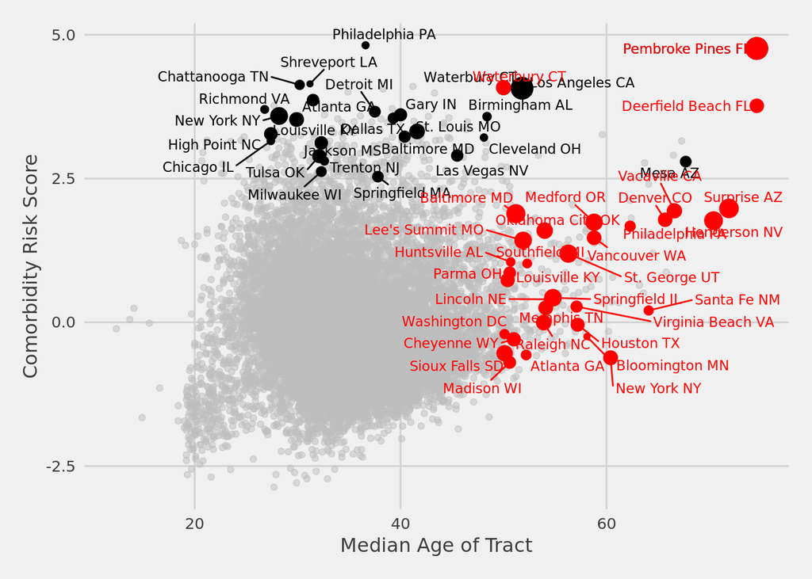

```r
#fh_cities <- fh_cities %>% mutate(comorbidity_risk_score = (CANCER_CrudePrev + STROKE_CrudePrev + CASTHMA_CrudePrev + COPD_CrudePrev + CHD_CrudePrev + OBESITY_CrudePrev + CSMOKING_CrudePrev + DIABETES_CrudePrev))

fh_cities <- fh_cities %>% filter(population_2010 > median(fh_cities$population_2010)) # filter by high population census tracts
fh_cities <- fh_cities %>% mutate(comorbidity_risk_score = (scale(CANCER_CrudePrev) + scale(STROKE_CrudePrev) + scale(CASTHMA_CrudePrev) + scale(COPD_CrudePrev) + scale(CHD_CrudePrev) + scale(OBESITY_CrudePrev) + scale(CSMOKING_CrudePrev) + scale(DIABETES_CrudePrev) + scale(KIDNEY_CrudePrev)))


fh_cities$comorbidity_risk_score <- scale(fh_cities$comorbidity_risk_score) # z-score the risk score
fh_cities <- fh_cities %>% filter(!is.na(median_age))

# top census tracts per state, but filtered for those that have a high risk score
top_per_state <- fh_cities %>% group_by(stateabbr) %>% top_n(1,comorbidity_risk_score) %>% ungroup() %>% filter(comorbidity_risk_score >= 2.5)
# top census tracts per state based on age, but filtered for those that have a high risk score
oldest_tracts <- fh_cities %>% group_by(stateabbr) %>% top_n(1,median_age) %>% ungroup() %>% filter(median_age >= 50)
top_both <- fh_cities %>% filter(comorbidity_risk_score > 2 & median_age >= 55)

### main plot
p <- ggplot(fh_cities, aes(median_age, comorbidity_risk_score))
p <- p + geom_point(alpha=0.5, color='gray')

p <- p + geom_point(data=top_per_state, aes(median_age, comorbidity_risk_score, size=population_2010))
p <- p + geom_text_repel(data=top_per_state, aes(median_age, comorbidity_risk_score, label=paste(placename, stateabbr)), size=3)

p <- p + geom_point(data=oldest_tracts, aes(median_age, comorbidity_risk_score, size=population_2010), color='red')
p <- p + geom_text_repel(data=oldest_tracts, aes(median_age, comorbidity_risk_score, label=paste(placename, stateabbr)),color='red', size=3)


p <- p + theme_fivethirtyeight() + theme(axis.title = element_text(), legend.position = 'none') + labs(x = 'Median Age of Tract', y = 'Comorbidity Risk Score')
p
```

## Comorbidity Risk Score and Lack of Access To Care

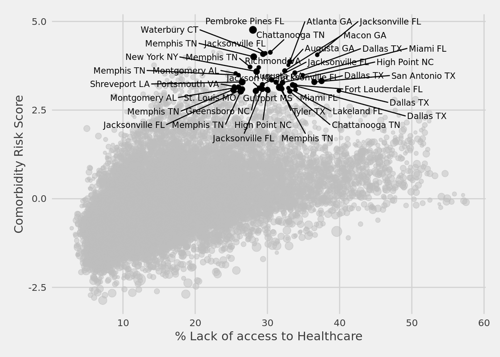

```r
lack_access <- fh_cities %>% filter(comorbidity_risk_score >= 3, ACCESS2_CrudePrev > 25)
p <- ggplot(fh_cities, aes(ACCESS2_CrudePrev, comorbidity_risk_score, size=population_2010))
p <- p + geom_point(alpha=0.5, color='gray')
p <- p + geom_point(data=lack_access, aes(ACCESS2_CrudePrev, comorbidity_risk_score), color='black')
p <- p + geom_text_repel(data=lack_access, aes(ACCESS2_CrudePrev, comorbidity_risk_score, label=paste(placename, stateabbr)),color='black ', size=3)
p <- p + theme_fivethirtyeight() + theme(axis.title = element_text(), legend.position = 'none') + labs(x = '% Lack of access to Healthcare', y = 'Comorbidity Risk Score')
p
```

## Comorbidity Risk Score, Age, and High Proportion of Positive Cases

```r
fh_covid_cases <- fh_cities %>% left_join(current_covid, by=c('stateabbr'='state')) %>% mutate(covid_percent = positive / (positive+negative))
```

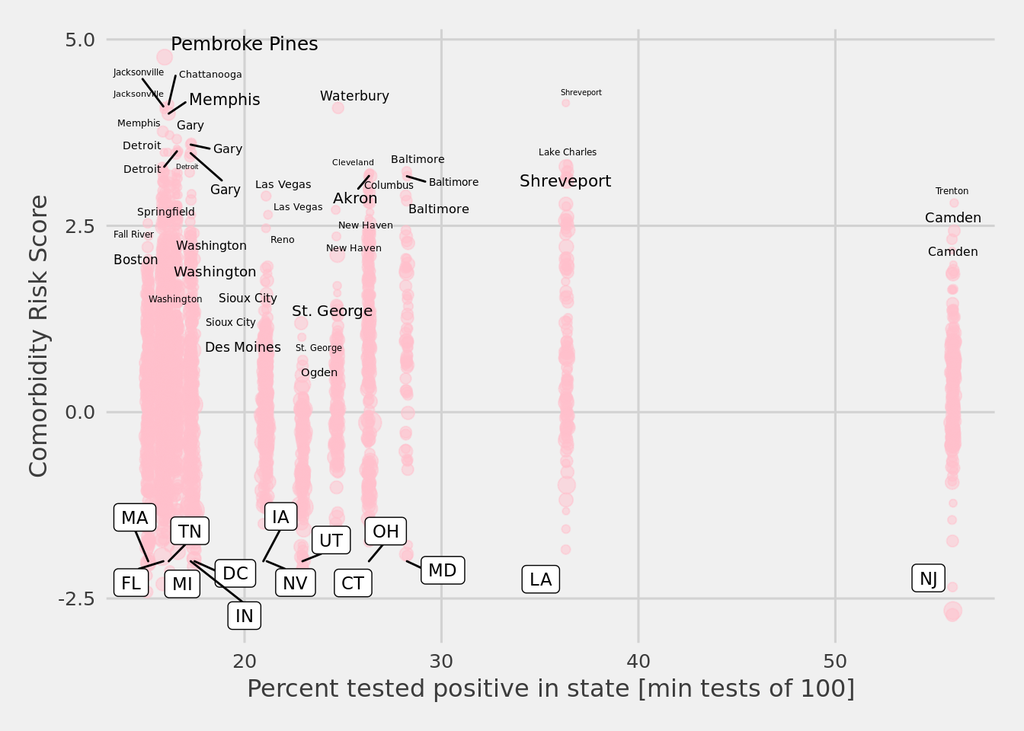

```r
top3_como_covid <- fh_covid_cases %>% group_by(covid_percent) %>% top_n(3, comorbidity_risk_score) %>% ungroup() %>% filter(covid_percent >= .15, total >= 100)
p <- ggplot(fh_covid_cases %>% filter(covid_percent >= .15, total >= 100), aes(covid_percent*100, comorbidity_risk_score, size=population_2010))
p <- p + geom_jitter(alpha=0.5, color='pink')
p <- p + geom_text_repel(data=top3_como_covid, aes(covid_percent*100, comorbidity_risk_score, label=placename))
p <- p + geom_label_repel(data=top3_como_covid %>% group_by(stateabbr) %>% top_n(1, comorbidity_risk_score), aes(covid_percent*100, -2, label=stateabbr), size=3)
p <- p + theme_fivethirtyeight() + theme(axis.title = element_text(), legend.position = 'none') + labs(x = 'Percent tested positive in state [min tests of 100]', y = 'Comorbidity Risk Score')
p
```

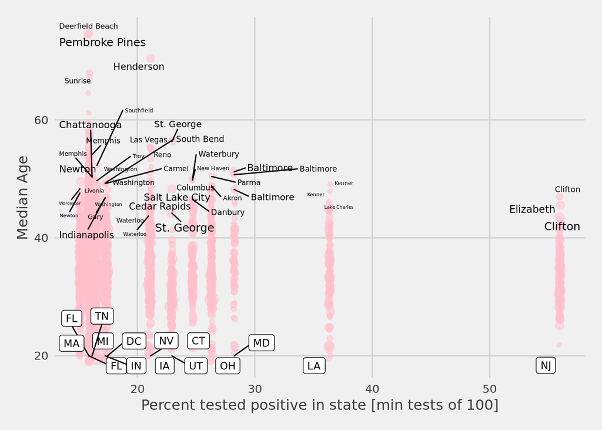

```r
top3_age_covid <- fh_covid_cases %>% group_by(covid_percent) %>% top_n(3, median_age) %>% ungroup() %>% filter(covid_percent >= .15, total >= 100)
p <- ggplot(fh_covid_cases %>% filter(covid_percent >= .15, total >= 100), aes(covid_percent*100, median_age, size=population_2010))
p <- p + geom_jitter(alpha=0.5, color='pink')
p <- p + geom_text_repel(data=top3_age_covid, aes(covid_percent*100, median_age, label=placename))
p <- p + geom_label_repel(data=top3_age_covid %>% group_by(stateabbr) %>% top_n(1, median_age), aes(covid_percent*100, 20, label=stateabbr), size=3)
p <- p + theme_fivethirtyeight() + theme(axis.title = element_text(), legend.position = 'none') + labs(x = 'Percent tested positive in state [min tests of 100]', y = 'Median Age')
p
```

## Senstivity Analyses

### Examine the top community/census tract for specific diseases, such as Cancer, Diabetes, Asthma, and CHD

```r
# first scale all
fh_covid_cases_sens <- fh_covid_cases %>% mutate(CANCER_CrudePrev=scale(CANCER_CrudePrev), STROKE_CrudePrev=scale(STROKE_CrudePrev), CASTHMA_CrudePrev=scale(CASTHMA_CrudePrev), COPD_CrudePrev=scale(COPD_CrudePrev), CHD_CrudePrev=scale(CHD_CrudePrev), OBESITY_CrudePrev=scale(OBESITY_CrudePrev), CSMOKING_CrudePrev=scale(CSMOKING_CrudePrev), DIABETES_CrudePrev=scale(DIABETES_CrudePrev), KIDNEY_CrudePrev=scale(KIDNEY_CrudePrev))


# show Asthma, CHD, T2D, cancer
fh_covid_long <- fh_covid_cases_sens[, c('fips_place_tract',  'CANCER_CrudePrev', 'DIABETES_CrudePrev', 'CASTHMA_CrudePrev', 'CHD_CrudePrev')] %>% gather('disease', 'score', -fips_place_tract)
```

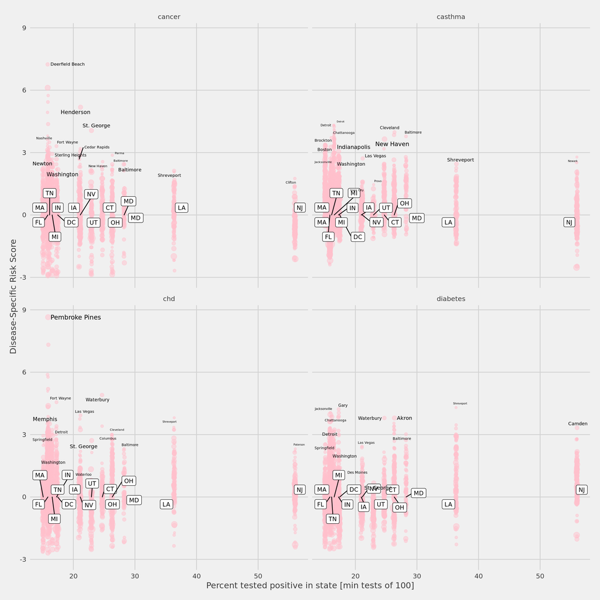

```r
fh_covid_long <- fh_covid_long %>% left_join(fh_covid_cases_sens %>% select(fips_place_tract, placename, stateabbr, population_2010, covid_percent, total) %>% unique(), by='fips_place_tract')

fh_covid_long$disease <- tolower(unlist(lapply(strsplit(fh_covid_long$disease, "_"), function(arr) {arr[[1]]})))

top_disease_covid <- fh_covid_long %>% group_by(covid_percent, disease) %>% top_n(1, score) %>% ungroup() %>% filter(covid_percent >= .15, total >= 100)

p <- p <- ggplot(fh_covid_long %>% filter(covid_percent >= .15, total >= 100), aes(covid_percent*100, score, size=population_2010))
p <- p + geom_jitter(alpha=0.5, color='pink')
p <- p + geom_label_repel(data=fh_covid_long %>% group_by(stateabbr, disease) %>% top_n(1, score) %>% ungroup() %>% filter(covid_percent >= .15, total >= 100), aes(covid_percent*100, 0, label=stateabbr), size=3)
p <- p + facet_wrap(.~disease, nrow=2)
p <- p + geom_text_repel(data=top_disease_covid, aes(covid_percent*100, score, label=placename))
p <- p + theme_fivethirtyeight() + theme(axis.title = element_text(), legend.position = 'none') + labs(x = 'Percent tested positive in state [min tests of 100]', y = 'Disease-Specific Risk Score')
p
```

We examine the similarities between the COVID-19 risk communities and specific disease: - a community in Shreveport ranks high for all of these candidate diseases, such including cancer, asthma, heart disease (chd in the figure), and diabetes. We conclude that Shreveport is a community of concern.

Differences: - The COVID-19 risk score for a community in Pembroke Pines, FL seems to be dominated by heart disease - The COVID-19 risk score for a community in Akron, OH and Camden, NJ seems to be dominated by diabetes

## News and social media updates on at-risk populations:

- https://www.nytimes.com/2020/03/12/health/coronavirus-midlife-conditions.html
- https://twitter.com/search?q=%23HighRiskCovid19&src=trend_click